# 06_project_rev02_02

**Комментарий 👉**

1. Вместо этого кода лучше использовать циклы.
2. Подпись к графику не верна - тут явно не 6 платформ.
3. Код очень длинный (а PEP8 определяет длину строки в 79 символов) - попробуй длинные - переносить, а между строками использовать пустые строки. Ну и желательно код комментировать, хотя бы коротко (что делаешь и каков будет результат - так твоим коллегам будет проще за твоей мыслью следить). Этот комментарий может относиться к нескольким ячейкам этой «тетрадки».

**Вывод:** потенциально прибыльными платформами являются PS4 и XOne - рекомендуется в них инвестировать.

6. Построим график «ящик с усами» по глобальным продажам игр в разбивке по платформам.

```python
games_filter_prognoz.sort_values(by='total_sales', ascending = False)
```

|  | name | platform | year_of_release | genre | na_sales | eu_sales | jp_sales | other_sales | critic_score | user_score | rating | total_sales |
| --- | --- | --- | --- | --- | --- | --- | --- | --- | --- | --- | --- | --- |
| 25 | Pokemon Ruby/Pokemon Sapphire | GBA | 2002 | Role-Playing | 6.06 | 3.90 | 5.38 | 0.50 | 150.0 | 150.0 |  | 15.84 |
| 31 | Call of Duty: Black Ops 3 | PS4 | 2015 | Shooter | 6.03 | 5.86 | 0.36 | 2.38 | 150.0 | 150.0 |  | 14.63 |
| 33 | Pokemon X/Pokemon Y | 3DS | 2013 | Role-Playing | 5.28 | 4.19 | 4.35 | 0.78 | 150.0 | 150.0 |  | 14.60 |
| 40 | Mario Kart 7 | 3DS | 2011 | Racing | 5.03 | 4.02 | 2.69 | 0.91 | 85.0 | 8.2 | E | 12.65 |
| 42 | Grand Theft Auto V | PS4 | 2014 | Action | 3.96 | 6.31 | 0.38 | 1.97 | 97.0 | 8.3 | M | 12.62 |
| ... | ... | ... | ... | ... | ... | ... | ... | ... | ... | ... | ... | ... |
| 15875 | Super Stardust Ultra VR | PS4 | 2016 | Shooter | 0.00 | 0.01 | 0.00 | 0.00 | 66.0 | 6.2 | E10+ | 0.01 |
| 15874 | Puyo Pop Fever | GC | 2004 | Puzzle | 0.01 | 0.00 | 0.00 | 0.00 | 72.0 | 150.0 | E | 0.01 |
| 15869 | Shinobi Koutsutsu | PSP | 2014 | Adventure | 0.00 | 0.00 | 0.01 | 0.00 | 150.0 | 150.0 |  | 0.01 |
| 15868 | Guild Wars: Factions | PC | 2006 | Role-Playing | 0.00 | 0.01 | 0.00 | 0.00 | 84.0 | 8.5 | T | 0.01 |
| 16441 | Winning Post 8 2016 | PSV | 2016 | Simulation | 0.00 | 0.00 | 0.01 | 0.00 | 150.0 | 150.0 |  | 0.01 |

6017 rows × 12 columns

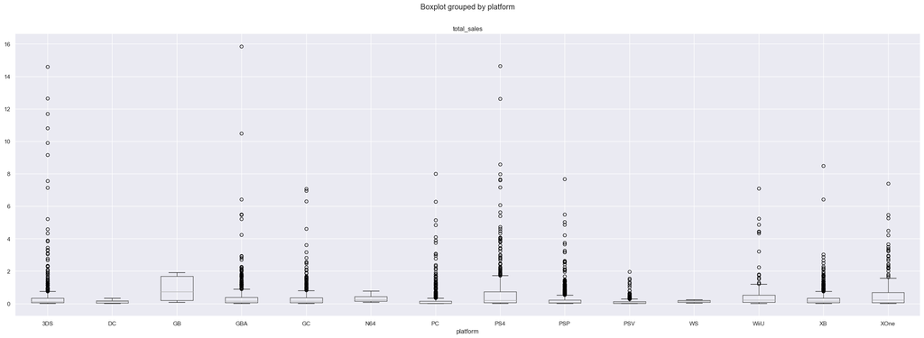

```python
games_filter_prognoz.boxplot(column='total_sales', by='platform',figsize=(30,10))
plt.show()
```

```python
data_platforms = [games_filter_prognoz[games_filter_prognoz['platform'] == 'GBA']['total_sales'],games_filter_prognoz[games_filter_prognoz['platform'] == 'PS4']['total_sales'], games_filter_prognoz[games_filter_prognoz['platform'] == '3DS']['total_sales']]
plt.show()
#@platform_prognoz[0]     GBA PS4 3DS XB PC PSP XOne WiiU GC PSV GB N64 DC WS
```

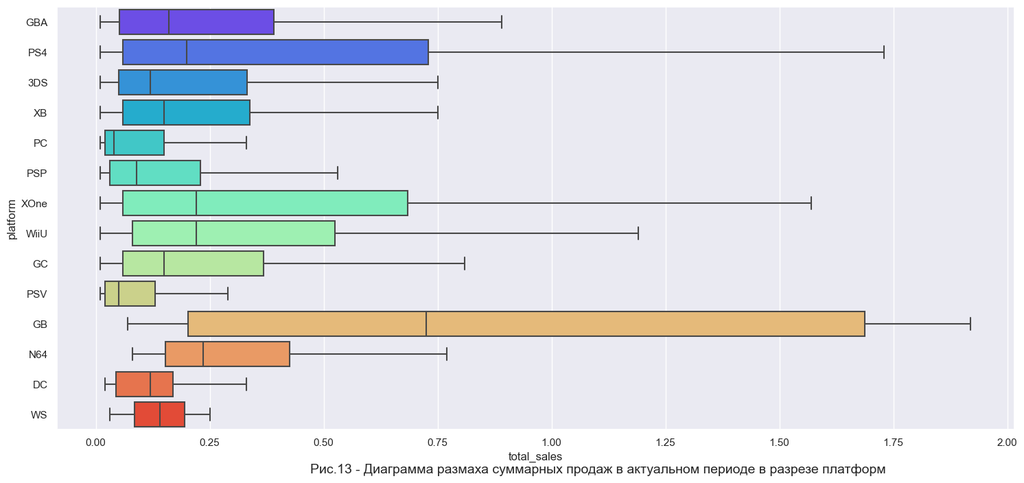

```python
sns.set(rc={'figure.figsize':(18,8)})
sns.boxplot(data=games_filter_prognoz, x = 'total_sales', y = 'platform',palette='rainbow', showfliers=False)#-для отсечки выбросов
plt.figtext(0.33, 0.03, "Рис.13 - Диаграмма размаха суммарных продаж в актуальном периоде в разрезе платформ", fontsize=14)
plt.show()
```

**Необходимо исправить ❌**

К сожалению, на этом графике **уверенно** сравнивать квартили (медиану, 25ый и 75ый) у части платформ не получается. Велика вероятность ошибки. Для более обоснованных выводов на основе **только графика** (иначе зачем такой **неговорящий график нужен**) нужно сделать дополнительный график, где будет отображена только нижняя часть boxplot-ов. Этого можно добиться, например, задав параметр ylim

То есть, я бы предложил после этого графика ещё один построить, в котором бы сами "ящики" были лучше видны. На том, что выше выбросы их фактически "забили". Попробуй использовать в параметре ylim, значение, которое ещё больше ограничит значение по OY "сверху" (например, ylim(0, 0.85). Ну и «строй» график большего размера (попробуй использовать: figsize=[20, 10].

Ну а в твоем случае, из-за того, что на графике не разобрать квартили - для точного сравнения "ящиков" мы вынуждены будем использовать describe().

```python
games_filter_prognoz[games_filter_prognoz['platform']=='GB']
```

|  | name | platform | year_of_release | genre | na_sales | eu_sales | jp_sales | other_sales | critic_score | user_score | rating | total_sales |
| --- | --- | --- | --- | --- | --- | --- | --- | --- | --- | --- | --- | --- |
| 886 | The Legend of Zelda: Oracle of Ages | GB | 2001 | Action | 0.92 | 0.53 | 0.41 | 0.06 | 150.0 | 150.0 |  | 1.92 |
| 918 | The Legend of Zelda: Oracle of Seasons | GB | 2001 | Adventure | 0.87 | 0.52 | 0.41 | 0.06 | 150.0 | 150.0 |  | 1.86 |
| 1019 | Harry Potter and the Sorcerer's Stone | GB | 2001 | Action | 0.94 | 0.62 | 0.10 | 0.07 | 150.0 | 150.0 |  | 1.73 |
| 1184 | Dragon Quest Monsters 2 | GB | 2001 | Role-Playing | 0.00 | 0.00 | 1.56 | 0.00 | 150.0 | 150.0 |  | 1.56 |
| 2301 | Pokemon Card GB2: Here Comes Team GR! | GB | 2001 | Strategy | 0.00 | 0.00 | 0.89 | 0.00 | 150.0 | 150.0 |  | 0.89 |
| 3540 | Hamtaro: Ham-Hams Unite! | GB | 2001 | Role-Playing | 0.00 | 0.00 | 0.56 | 0.00 | 150.0 | 150.0 |  | 0.56 |
| 4863 | From TV Animation One Piece: Yume no Lufy Kaiz... | GB | 2001 | Role-Playing | 0.00 | 0.00 | 0.39 | 0.00 | 150.0 | 150.0 |  | 0.39 |
| 8903 | Star Ocean: Blue Sphere | GB | 2001 | Role-Playing | 0.00 | 0.00 | 0.14 | 0.00 | 150.0 | 150.0 |  | 0.14 |
| 9715 | Medarot 4: Kabuto / Kuwagata Version | GB | 2001 | Role-Playing | 0.00 | 0.00 | 0.12 | 0.00 | 150.0 | 150.0 |  | 0.12 |
| 11664 | Mega Man Xtreme 2 | GB | 2001 | Platform | 0.00 | 0.00 | 0.07 | 0.00 | 150.0 | 150.0 |  | 0.07 |

**Вывод:** Продажи **XOne** и **PS4** сильно выделяются на фоне остальных-это мастодонты рынка. Также выделяются продажи по платформе **GB** - некоторые игры имели большой успех, но только в 2001 года, далее продаж по данной платформе не было. Стоит отметить большие выбросы в прождажах у платформ **GBA**, **PS4**, **3DS** - некоторые игры данных платформ пользовались огромным спросом.

7. Посмотрим, как влияют на продажи внутри одной популярной платформы отзывы пользователей и критиков:построим диаграмму рассеяния и посчитаем корреляцию между отзывами и продажами.

```python
# посчитаем корреляцию между отзывами и продажами в общем случае
(games_filter_prognoz[['critic_score','user_score','na_sales','eu_sales','jp_sales','other_sales']].corr()
 .style.background_gradient(cmap='coolwarm'))
```

|  | critic_score | user_score | na_sales | eu_sales | jp_sales | other_sales |
| --- | --- | --- | --- | --- | --- | --- |
| critic_score | 1.000000 | 0.714079 | -0.103221 | -0.067589 | 0.099043 | -0.070865 |
| user_score | 0.714079 | 1.000000 | -0.175161 | -0.152339 | 0.058717 | -0.152963 |
| na_sales | -0.103221 | -0.175161 | 1.000000 | 0.688856 | 0.385757 | 0.646764 |
| eu_sales | -0.067589 | -0.152339 | 0.688856 | 1.000000 | 0.320920 | 0.829859 |
| jp_sales | 0.099043 | 0.058717 | 0.385757 | 0.320920 | 1.000000 | 0.239539 |
| other_sales | -0.070865 | -0.152963 | 0.646764 | 0.829859 | 0.239539 | 1.000000 |

**Комментарий 👉**

Надо не в "общем случае", а для 2-3х конкретных платформ помимо PS4 (то, что делаешь ниже).

```python
# посчитаем корреляцию между отзывами и продажами для платформы PS4
(games_filter_prognoz.query('platform=="PS4"')[['critic_score','user_score','na_sales','eu_sales','jp_sales','other_sales']].corr().style.background_gradient(cmap='coolwarm'))
```

|  | critic_score | user_score | na_sales | eu_sales | jp_sales | other_sales |
| --- | --- | --- | --- | --- | --- | --- |
| critic_score | 1.000000 | 0.907708 | -0.045634 | -0.060757 | 0.125251 | -0.054019 |
| user_score | 0.907708 | 1.000000 | -0.123376 | -0.135165 | 0.081181 | -0.134034 |
| na_sales | -0.045634 | -0.123376 | 1.000000 | 0.785362 | 0.472981 | 0.944259 |
| eu_sales | -0.060757 | -0.135165 | 0.785362 | 1.000000 | 0.464563 | 0.944698 |
| jp_sales | 0.125251 | 0.081181 | 0.472981 | 0.464563 | 1.000000 | 0.496467 |
| other_sales | -0.054019 | -0.134034 | 0.944259 | 0.944698 | 0.496467 | 1.000000 |

**Необходимо исправить ❌**

Если бы в 'user_score' и 'critic_score' мы оставили бы NaN (не заполняли «заглушкой» == 150), то .corr бы их при расчете корреляций не стал использовать (и мы получили бы коэффициенты для **реальных** оценок). Сейчас же своё влияние на значения коэффициентов корреляции имеют и искусственно сгенерированные нами оценки, за фактическую корректность которых мы ручаться совсем не можем.

Линейная зависимость между оценками критиков и пользователей и продажами минимальна, либо взаимосвязь более сложная.

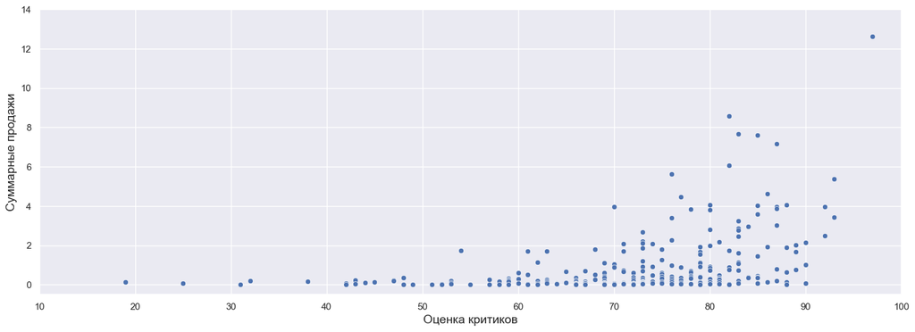

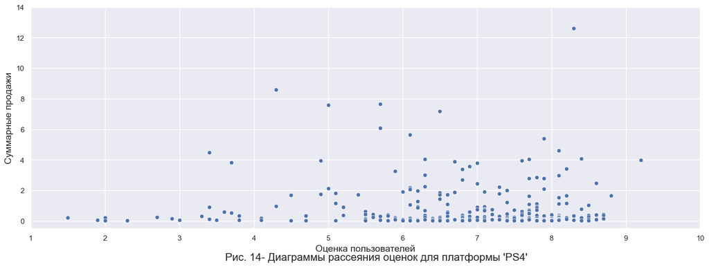

```python
# построим диаграмму рассеяния для платформы 'PS4'
sns.set(rc={'figure.figsize':(18,6)})
critic_score_total_sales = sns.scatterplot(data=games_filter_prognoz.query('platform == "PS4"'), x="critic_score", y="total_sales",
    sizes=(20, 500), legend=False)
#critic_score_total_sales.axes.figtext("Диаграмма рассеяния оценок для платформы 'PS4'", fontsize=16)
critic_score_total_sales.set(xlim=(10, 100), ylim=(-0.5, 14))
critic_score_total_sales.set_xlabel("Оценка критиков", fontsize=14)
critic_score_total_sales.set_ylabel("Суммарные продажи", fontsize=14)
plt.show()

critic_score_total_sales = sns.scatterplot(data=games_filter_prognoz.query('platform == "PS4"'), x="user_score", y="total_sales",
    sizes=(20, 500), legend=False)
critic_score_total_sales.set(xlim=(1, 10), ylim=(-0.5, 14))
critic_score_total_sales.set_xlabel("Оценка пользователей", fontsize=14)
critic_score_total_sales.set_ylabel("Суммарные продажи", fontsize=14)
plt.figtext(0.35, 0.00, "Рис. 14- Диаграммы рассеяния оценок для платформы 'PS4'", fontsize=16)
plt.show()
```

**ОТЛИЧНО! 👍**

Здорово! Ты понимаешь, что формулировать, что якобы коэффициент корреляции (Пирсона) между 2 переменными (в нашем случае между "total_sales" и "critic_score") есть показатель того, что **на количество продаж влияет оценка критиков** - неверно. А ведь примерно в 70% студенческих работ именно такое и встречается.

Действительно, коэффициент свидетельствует **о наличии или отсутствии линейной связи** между переменными, и **измеряет выраженность** этой связи. Другими словами, коэффициент корреляции - это инструмент, с помощью которого можно проверить гипотезу о **линейной** зависимости и измерить степень этой зависимости.

То есть, влияния оценок на продажи нет. Коэффициент корреляции Пирсона не про это. Он про линейную зависимость 2-х переменных. И ещё, это коэффициент **НЕ ОБЪЯСНЯЕТ** зависимость, он **НЕ ГОВОРИТ** почему наблюдается такой эффект, но просто констатирует факт, что корреляция наблюдается (например, "мы видим, что те игры, которым наши эксперты дают высокие оценки - продаются лучше". А вот почему они продаются лучше - можно только предполагать ... разные причины могут быть).

8. Соотнесем выводы с продажами игр на других платформах.

```python
# посчитаем корреляцию между отзывами и продажами для платформы XOne
(games_filter_prognoz.query('platform=="XOne"')[['critic_score','user_score','na_sales','eu_sales','jp_sales','other_sales']].corr().style.background_gradient(cmap='coolwarm'))
```

|  | critic_score | user_score | na_sales | eu_sales | jp_sales | other_sales |
| --- | --- | --- | --- | --- | --- | --- |
| critic_score | 1.000000 | 0.756712 | -0.072145 | -0.065785 | -0.038152 | -0.071670 |
| user_score | 0.756712 | 1.000000 | -0.147090 | -0.135229 | -0.069330 | -0.148254 |
| na_sales | -0.072145 | -0.147090 | 1.000000 | 0.765367 | 0.425725 | 0.988088 |
| eu_sales | -0.065785 | -0.135229 | 0.765367 | 1.000000 | 0.421071 | 0.852986 |
| jp_sales | -0.038152 | -0.069330 | 0.425725 | 0.421071 | 1.000000 | 0.441717 |
| other_sales | -0.071670 | -0.148254 | 0.988088 | 0.852986 | 0.441717 | 1.000000 |

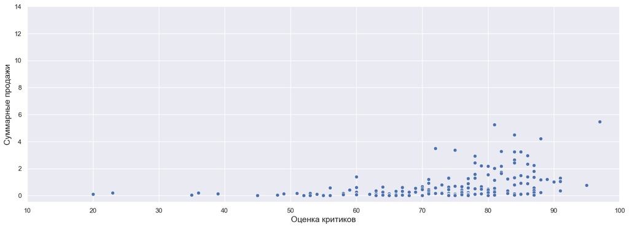

[figure not shown]

```python
# построим диаграмму рассеяния для платформы 'XOne'
sns.set(rc={'figure.figsize':(18,6)})
critic_score_total_sales = sns.scatterplot(data=games_filter_prognoz.query('platform == "XOne"'), x="critic_score", y="total_sales",
    sizes=(20, 500), legend=False)
#critic_score_total_sales.axes.figtext("Диаграмма рассеяния оценок для платформы 'PS4'", fontsize=16)
critic_score_total_sales.set(xlim=(10, 100), ylim=(-0.5, 14))
critic_score_total_sales.set_xlabel("Оценка критиков", fontsize=14)
critic_score_total_sales.set_ylabel("Суммарные продажи", fontsize=14)
plt.show()

critic_score_total_sales = sns.scatterplot(data=games_filter_prognoz.query('platform == "XOne"'), x="user_score", y="total_sales",
    sizes=(20, 500), legend=False)
critic_score_total_sales.set(xlim=(1, 10), ylim=(-0.5, 14))
critic_score_total_sales.set_xlabel("Оценка пользователей", fontsize=14)
critic_score_total_sales.set_ylabel("Суммарные продажи", fontsize=14)
plt.figtext(0.35, 0.00, "Рис.15 - Диаграммы рассеяния оценок для платформы 'PS4'", fontsize=16)
plt.show()
```

```python
# посчитаем корреляцию между отзывами и продажами для платформы WiiU
(games_filter_prognoz.query('platform=="WiiU"')[['critic_score','user_score','na_sales','eu_sales','jp_sales','other_sales']].corr().style.background_gradient(cmap='coolwarm'))
```

|  | critic_score | user_score | na_sales | eu_sales | jp_sales | other_sales |
| --- | --- | --- | --- | --- | --- | --- |
| critic_score | 1.000000 | 0.800123 | -0.117810 | -0.138377 | -0.054747 | -0.122799 |
| user_score | 0.800123 | 1.000000 | -0.150182 | -0.185680 | -0.076486 | -0.158824 |
| na_sales | -0.117810 | -0.150182 | 1.000000 | 0.958772 | 0.808387 | 0.994516 |
| eu_sales | -0.138377 | -0.185680 | 0.958772 | 1.000000 | 0.860098 | 0.976412 |
| jp_sales | -0.054747 | -0.076486 | 0.808387 | 0.860098 | 1.000000 | 0.824345 |
| other_sales | -0.122799 | -0.158824 | 0.994516 | 0.976412 | 0.824345 | 1.000000 |

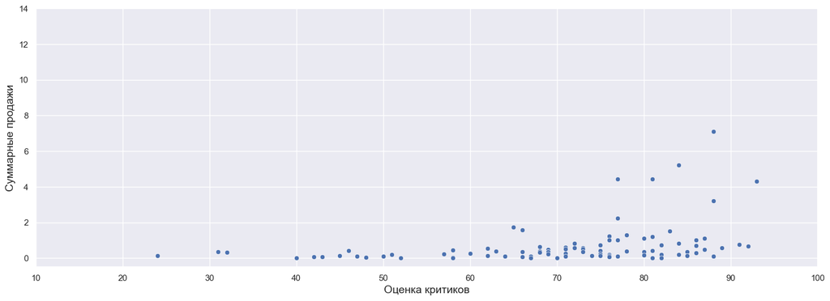

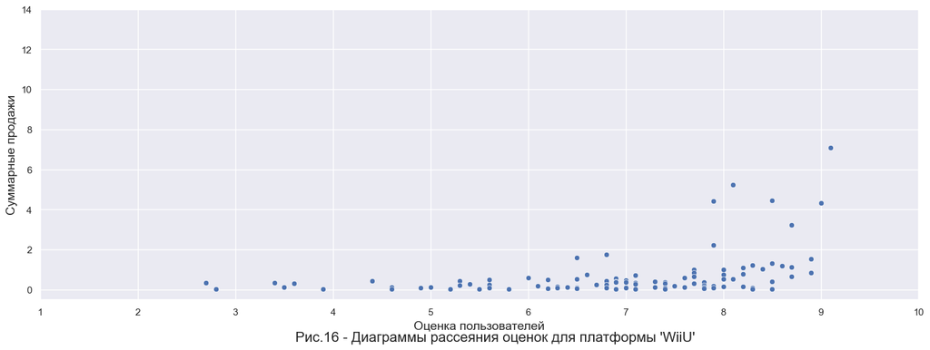

```python
# построим диаграмму рассеяния для платформы 'WiiU'
sns.set(rc={'figure.figsize':(18,6)})
critic_score_total_sales = sns.scatterplot(data=games_filter_prognoz.query('platform == "WiiU"'), x="critic_score", y="total_sales",
    sizes=(20, 500), legend=False)
#critic_score_total_sales.axes.figtext("Диаграмма рассеяния оценок для платформы 'WiiU'", fontsize=16)
critic_score_total_sales.set(xlim=(10, 100), ylim=(-0.5, 14))
critic_score_total_sales.set_xlabel("Оценка критиков", fontsize=14)
critic_score_total_sales.set_ylabel("Суммарные продажи", fontsize=14)
plt.show()

critic_score_total_sales = sns.scatterplot(data=games_filter_prognoz.query('platform == "WiiU"'), x="user_score", y="total_sales",
    sizes=(20, 500), legend=False)
critic_score_total_sales.set(xlim=(1, 10), ylim=(-0.5, 14))
critic_score_total_sales.set_xlabel("Оценка пользователей", fontsize=14)
critic_score_total_sales.set_ylabel("Суммарные продажи", fontsize=14)
plt.figtext(0.35, 0.00, "Рис.16 - Диаграммы рассеяния оценок для платформы 'WiiU'", fontsize=16)
plt.show()
```

9. Посмотрим на общее распределение игр по жанрам.

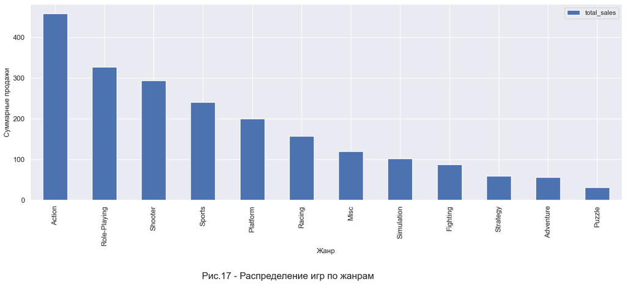

```python
(games_filter_prognoz.pivot_table(index='genre',values='total_sales', aggfunc='sum')
.sort_values(by='total_sales', ascending=False).plot(kind='bar',figsize=(18,6)))
plt.xlabel("Жанр", fontsize=12)
plt.ylabel('Суммарные продажи', fontsize=12)
plt.xticks(fontsize=12)
plt.yticks(fontsize=12)
plt.figtext(0.35, -0.2, "Рис.17 - Распределение игр по жанрам", fontsize=16)
plt.show()
```

**Вывод:** наиболее популярны игры жанров: экшн,ролевые игры, стрелялки, спортивные, платформер - игры, вызывающие эмоции от происходящего; наименее популярные жанры: симуляции, бои, стратегии, приключения и пазлы -игры, в которых необходимо думать, планировать. Стоит отметить, что на выявленную закономерность также повлияла стоимость игр: производство игр, попавших в популярную группу, обходятся существенно дороже.

**Необходимо исправить ❌**

Здесь у нас возникла проблема: по суммарным (sum, count) объемам продаж у тебя получилось, что явный лидер - игры в жанре Экшн. Если же ты рассмотришь медианные или средние (mean) значения, то результат поменяется в пользу Шуттеров. Учти тот факт, что игр в жанре Экшн выпускается значительно больше, чем других (в 1,5-2 раза). Доля количества игр в жанре «стрелялок» - всего лишь 8%. Очевидно, что в жанре Экшн присутствует большое количество непопулярных игр с низкими объёмами продаж, в результате чего общий объём продаж жанра "раздут" и берётся количеством, а не качеством. Медиана учитывает не только слишком большие\маленькие значения относительно среднего, но и их количество. Поэтому брать итоговые результаты медианы или среднего более корректно.

В сухом остатке: попробуй рассмотреть не общие продажи, а медианные (или средние). Общие продажи - плохая метрика для поиска наиболее прибыльного жанра. За высокими показателями общих продаж может скрываться множество мелких игр с низкими продажами. Или 2-3 звезды и куча провалов. Лучше найти жанр, где игры стабильно приносят высокий доход - для этого стоит рассмотреть средние (или медианные продажи). Я думаю, что анализ медианных показателей позволит тебе найти жанр, который приносит высокий доход.

# 4. Составим портрет пользователя каждого региона

1.Определим для пользователя каждого региона (NA, EU, JP) самые популярные платформы (топ-5)

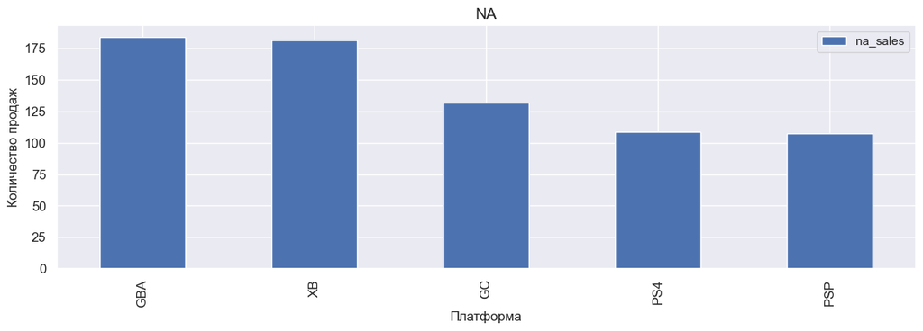

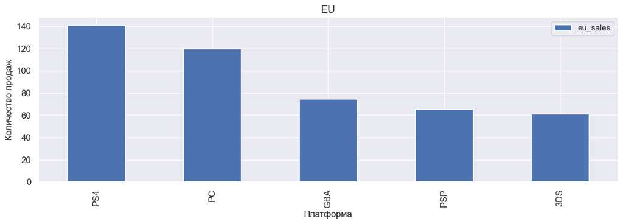

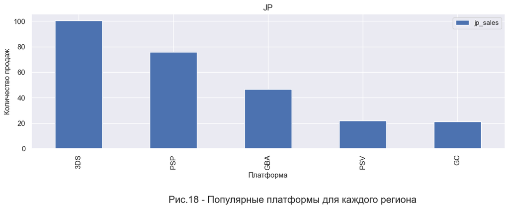

```python
#Популярные платформы для региона NA
na_sales = games_filter_prognoz.pivot_table(index='platform',values='na_sales', aggfunc='sum').sort_values(by='na_sales', ascending=False)[:5]
na_sales.plot(kind='bar',figsize=(14,4))
plt.xlabel("Платформа", fontsize=12)
plt.ylabel('Количество продаж', fontsize=12)
plt.xticks(fontsize=12)
plt.yticks(fontsize=12)
plt.title('NA', fontsize=14)
#plt.figtext(0.35, -0.2, "Рис. - Популярные платформы для региона NA", fontsize=16)
plt.show()

#Популярные платформы для региона EU
eu_sales = games_filter_prognoz.pivot_table(index='platform',values='eu_sales', aggfunc='sum').sort_values(by='eu_sales', ascending=False)[:5]
eu_sales.plot(kind='bar',figsize=(14,4))
plt.xlabel("Платформа", fontsize=12)
plt.ylabel('Количество продаж', fontsize=12)
plt.xticks(fontsize=12)
plt.yticks(fontsize=12)
plt.title('EU', fontsize=14)
#plt.figtext(0.35, -0.2, "Рис. - Популярные платформы для региона EU", fontsize=16)
plt.show()

#Популярные платформы для региона JP
jp_sales = games_filter_prognoz.pivot_table(index='platform',values='jp_sales', aggfunc='sum').sort_values(by='jp_sales', ascending=False)[:5]
jp_sales.plot(kind='bar',figsize=(14,4))
plt.xlabel("Платформа", fontsize=12)
plt.ylabel('Количество продаж', fontsize=12)
plt.xticks(fontsize=12)
plt.yticks(fontsize=12)
plt.title('JP', fontsize=14)
plt.figtext(0.35, -0.2, "Рис.18 - Популярные платформы для каждого региона", fontsize=16)
plt.show()
```

```python
print('ТОП-5 самых популярных платформ в Северной Америке:',*na_sales[:5].index)
print('ТОП-5 самых популярных платформ в Европе:',*eu_sales[:5].index)
print('ТОП-5 самых популярных платформ в Японии:',*jp_sales[:5].index)
```

```
ТОП-5 самых популярных платформ в Северной Америке: GBA XB GC PS4 PSP
ТОП-5 самых популярных платформ в Европе: PS4 PC GBA PSP 3DS
ТОП-5 самых популярных платформ в Японии: 3DS PSP GBA PSV GC
```

```python
# посчитаем долю продаж в Северной Америке
total_sales = games_filter_prognoz.pivot_table(index='platform', values='total_sales', aggfunc='sum')# переменной присваиваем сумму общих продаж по всем платформам
percent_sales_na = (na_sales['na_sales'] / total_sales['total_sales']* 100)#. # доля продаж в Северной Америке
print('Доля продаж в Северной Америке:\n',percent_sales_na.sort_values(ascending=False)[:5])
print()
# посчитаем долю продаж в Европе
percent_sales_eu = (eu_sales['eu_sales'] / total_sales['total_sales']* 100)#. # доля продаж в Европе
print('Доля продаж в Европе:\n',percent_sales_eu.sort_values(ascending=False)[:5])
print()
# посчитаем долю продаж в Японии
percent_sales_jp = (jp_sales['jp_sales'] / total_sales['total_sales']* 100)#. # доля продаж в Европе
print('Доля продаж в Японии:\n',percent_sales_jp.sort_values(ascending=False)[:5])
```

```
Доля продаж в Северной Америке:
 platform
XB     72.360125
GC     67.066538
GBA    58.844027
PSP    37.049701
PS4    34.615140
dtype: float64

Доля продаж в Европе:
 platform
PC     59.628966
PS4    44.913096
GBA    23.838752
3DS    23.765564
PSP    22.664318
dtype: float64

Доля продаж в Японии:
 platform
PSV    40.587251
3DS    39.028742
PSP    26.207992
GBA    14.884435
GC     10.847354
dtype: float64
```

**Комментарий 👉**

**Однако игровая платформа PS2 пользуется спросом во всех регионах** - где это видно?

**КОММЕНТАРИЙ СТУДЕНТА**

Допущена опечатка: вместо **PS2** должно быть наименование платформы **PSP**

2. Определим для пользователя каждого региона (NA, EU, JP) самые популярные жанры (топ-5).

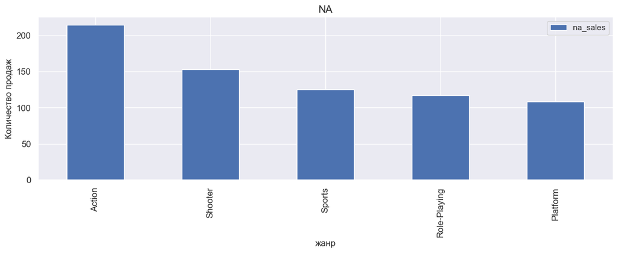

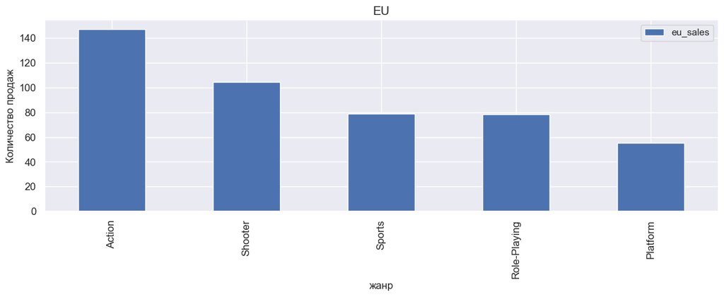

[figure not shown]

```python
#популярные жанры в Северной Америке
(games_filter_prognoz.pivot_table(index='genre', values='na_sales', aggfunc='sum')
 .sort_values(by='na_sales', ascending=False)[:5].plot(kind='bar',figsize=(14,4)))
plt.xlabel("жанр", fontsize=12)
plt.ylabel('Количество продаж', fontsize=12)
plt.xticks(fontsize=12)
plt.yticks(fontsize=12)
plt.title('NA', fontsize=14)

# популярные жанры в Европе
(games_filter_prognoz.pivot_table(index='genre', values='eu_sales', aggfunc='sum')
 .sort_values(by='eu_sales', ascending=False)[:5].plot(kind='bar',figsize=(14,4)))
plt.xlabel("жанр", fontsize=12)
plt.ylabel('Количество продаж', fontsize=12)
plt.xticks(fontsize=12)
plt.yticks(fontsize=12)
plt.title('EU', fontsize=14)

# популярные жанры в Японии
(games_filter_prognoz.pivot_table(index='genre', values='jp_sales', aggfunc='sum')
 .sort_values(by='jp_sales', ascending=False)[:5].plot(kind='bar',figsize=(14,4)))
plt.xlabel("жанр", fontsize=12)
plt.ylabel('Количество продаж', fontsize=12)
plt.xticks(fontsize=12)
plt.yticks(fontsize=12)
plt.title('JP', fontsize=14)

plt.figtext(0.35, -0.3, "Рис.19 - Популярные платформы для каждого региона", fontsize=16)
plt.show()
```

**ОТЛИЧНО! 👍**

3. Определим влияет ли рейтинг ESRB на продажи в отдельном регионе (NA, EU, JP)

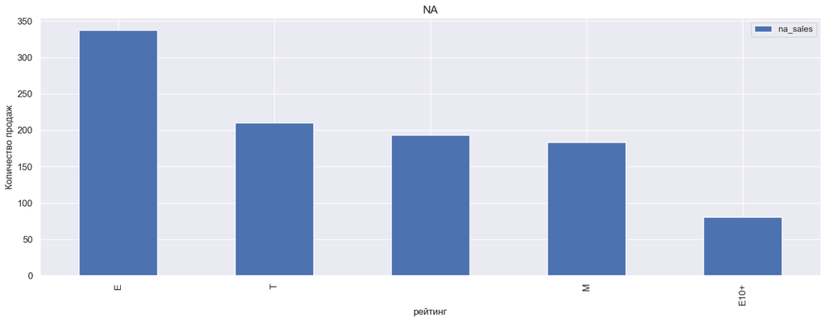

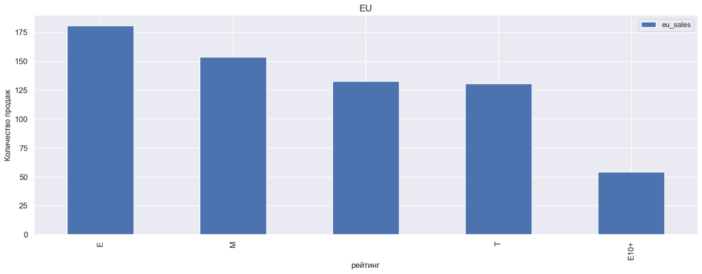

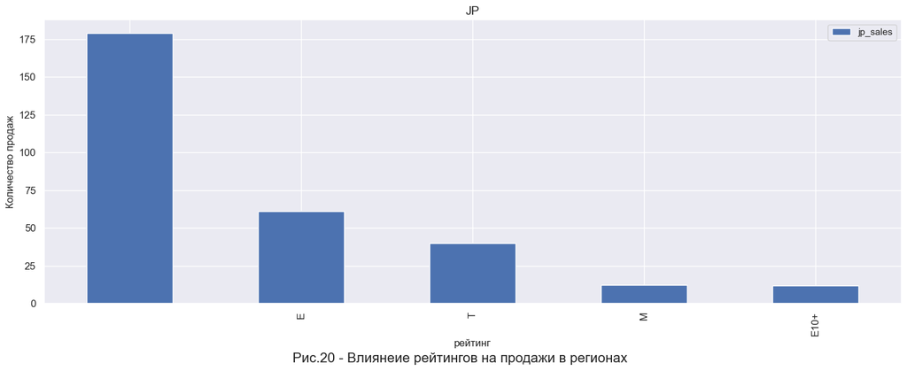

```python
# рейтинги ESRB на продажи в  Северной Америке
(games_filter_prognoz.pivot_table(index='rating',values='na_sales', aggfunc='sum')
 .sort_values(by='na_sales',ascending=False)[:5].plot(kind='bar',figsize=(18,6)))
plt.xlabel("рейтинг", fontsize=12)
plt.ylabel('Количество продаж', fontsize=12)
plt.xticks(fontsize=12)
plt.yticks(fontsize=12)
plt.title('NA', fontsize=14)
plt.show()

# рейтинги ESRB на продажи в Европе
(games_filter_prognoz.pivot_table(index='rating',values='eu_sales', aggfunc='sum')
 .sort_values(by='eu_sales',ascending=False)[:5].plot(kind='bar',figsize=(18,6)))
plt.xlabel("рейтинг", fontsize=12)
plt.ylabel('Количество продаж', fontsize=12)
plt.xticks(fontsize=12)
plt.yticks(fontsize=12)
plt.title('EU', fontsize=14)
plt.show()

# рейтинги ESRB на продажи в Японии
(games_filter_prognoz.pivot_table(index='rating',values='jp_sales', aggfunc='sum')
 .sort_values(by='jp_sales',ascending=False)[:5].plot(kind='bar',figsize=(18,6)))
plt.xlabel("рейтинг", fontsize=12)
plt.ylabel('Количество продаж', fontsize=12)
plt.xticks(fontsize=12)
plt.yticks(fontsize=12)
plt.title('JP', fontsize=14)

plt.figtext(0.35, -0.05, "Рис.20 - Влиянеие рейтингов на продажи в регионах", fontsize=16)
plt.show()
```

**ОТЛИЧНО! 👍**

Один из подводных камней этого проекта. Суть его в том, что часто студенты в самом начале «тетрадки» пропуски в 'rating' не обрабатывают, оставляют NaN, и соответственно во время анализа и/или построении графиков игры без рейтингов «теряются».

**Вывод:** зависимость от рейтинга отслеживается во всех трех регионах

**ОТЛИЧНО! 👍**

**В Японии самые высокие рейтинги у игр, в которых категории не определенны, видимо связано это с менталитетом японцев** - рейтинг ESRB - это американский рейтинг, а в Японии есть своё рейтинговое агентство (CERO). Получается, что Япония страна со своим менталитетом. И твой анализ показывает, что Японцы в игры-то играют не такие, как весь прочий мир и жанры игр там популярны совсем другие, нежели в остальном мире, да и на рейтинги (не своего агентства) не очень то внимание обращают.

# 5. Проверим гипотезы

Пороговое значение alpha примем равным 0.05

Осуществим проверку гипотез о равенстве средних двух генеральных совокупностей (двухстороннюю): сначала формулируется нулевая гипотеза H₀ о равенстве, далее формулируется альтернативная гипотеза, опровергающая утверждение H₀.

H0: Средние пользовательские рейтинги платформ Xbox One и PC одинаковые  
H1: Средние пользовательские рейтинги платформ Xbox One и PC разные

```python
Xbox_One = games_filter_prognoz.query('(platform=="XOne") and (0 < user_score < 100 )')['user_score']
print('Количество игр на платформе Xbox One:', Xbox_One.count())
PC = games_filter_prognoz.query('(platform=="PC")and (0 < user_score < 100 )').user_score
print('Количество игр на платформе PC:',len(PC))
```

```
Количество игр на платформе Xbox One: 182
Количество игр на платформе PC: 728
```

```python
# проверяем дисперсии выборок не равенство
if np.var(Xbox_One)==np.var(PC):
    print('True')
else:
    print('False')
```

```
False
```

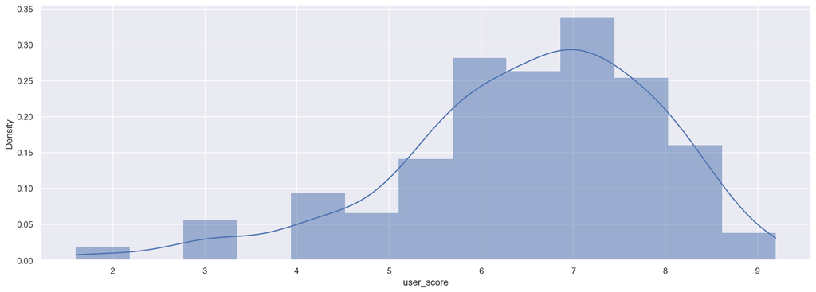

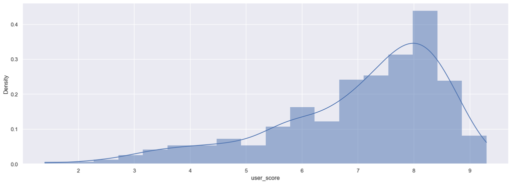

```python
# визуализируем распределения
sns.set(rc={'figure.figsize':(18,6)})
sns.histplot(Xbox_One,kde=True, stat="density", linewidth=0)
plt.show()
sns.histplot(PC, kde=True, stat="density", linewidth=0)
plt.show()
plt.figtext(0.3, -0.05, "Рис. 21 - Распределение рейтинга выборок" )
plt.show()
```

```python
statistics, p = st.ttest_ind(Xbox_One,PC, equal_var=False)
print('Statistics=%.3f, p=%.3f' % (statistics, p))

alpha = 0.05 # 5% критический уровень статистической значимости
if p > alpha:
    print('Средние пользовательские рейтинги платформ Xbox One и PC одинаковые (не получилось отвергнуть H0)')
else:
    print('Средние пользовательские рейтинги платформ Xbox One и PC разные (отвергаем H0)')
```

```
Statistics=-4.311, p=0.000
Средние пользовательские рейтинги платформ Xbox One и PC разные (отвергаем H0)
```

H0: Средние пользовательские рейтинги жанров Action и Sports одинаковые  
H1: Средние пользовательские рейтинги жанров Action и Sports разные

```python
Action = games_filter_prognoz.query('(genre=="Action") and (0<user_score<100)')['user_score']
print('Количество игр жанра Action:', Action.count())
Sports = games_filter_prognoz.query('(genre=="Sports") and (0<user_score<100)').user_score
print('Количество игр жанра Sports:', Sports.count())
```

```
Количество игр жанра Action: 766
Количество игр жанра Sports: 414
```

```python
# проверяем дисперсии выборок не равенство
if np.var(Action)==np.var(Sports):
    print('True')
else:
    print('False')
```

```
False
```

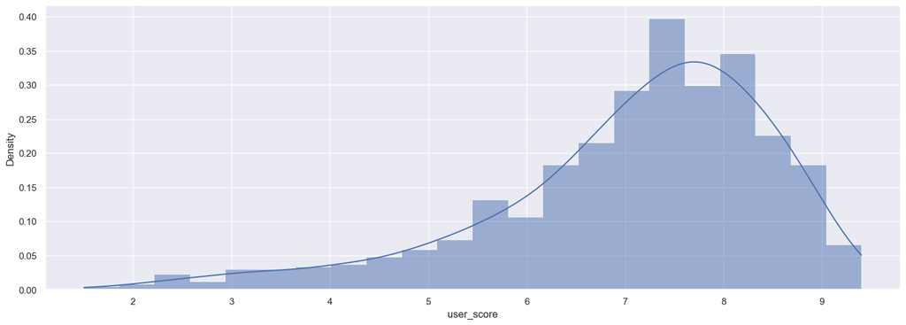

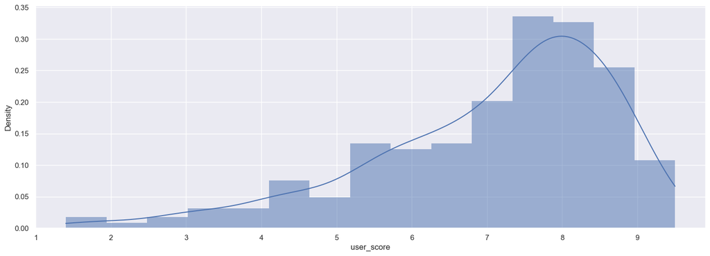

```python
# визуализируем распределения
sns.set(rc={'figure.figsize':(18,6)})
sns.histplot(Action,kde=True, stat="density", linewidth=0)
plt.show()
sns.histplot(Sports, kde=True, stat="density", linewidth=0)
plt.show()
plt.figtext(0.3, -0.05, "Рис.22 - Распределение рейтинга выборок" )
plt.show()
```

```python
statistics, p = st.ttest_ind(Action,Sports, equal_var=False)
print('Statistics=%.3f, p=%.3f' % (statistics, p))

alpha = 0.05 # 5% критический уровень статистической значимости
if p > alpha:
    print('Средние пользовательские рейтинги жанров Action и Sports одинаковые (не получилось отвергнуть H0)')
else:
    print('Средние пользовательские рейтинги жанров Action и Sports разные (отвергаем H0)')
```

```
Statistics=0.027, p=0.978
Средние пользовательские рейтинги жанров Action и Sports одинаковые (не получилось отвергнуть H0)
```

**Вывод:** пользовательские рейтинги для платформ Xbox и PC различны. Средние пользовательские рейтинги жанров Action (англ. «действие») и Sports (англ. «виды спорта») одинаковые.

**ОТЛИЧНО! 👍**

Очень хорошо, что ты не забываешь отфильтровать «заглушки» / NaN значения.

Также верно и то, что мы используем здесь двусторонний тест.

https://allatambov.github.io/psms/pdf/hypo-test.pdf

# 6. Вывод:

Проверка гипотез показала, что:

- пользовательские рейтинги для платформ Xbox и PC различны.
- средние пользовательские рейтинги жанров Action (англ. «действие») и Sports (англ. «виды спорта») одинаковые.

**Необходимо исправить ❌**

После исправления красных комментариев надо будет ещё раз пересмотреть выводы в этом финальном разделе, я уверен, что некоторые акценты сместятся и твой вывод поменяется.

# Результат ревью:

Я отмечаю высокий уровень твоей программистской подготовки. Ты используешь продвинутые концепции языка Python и библиотеки pandas. Всё это в целом упрощает твой код и одновременно показывает твой уровень владения инструментами.

Ты умело применяешь графические библиотеки (matplotlib / seaborn), выбираешь для визуализации ровно те типы графиков, которые нужны. Очень хорошо, что оси на графиках подписаны и сами они имеют понятные названия.

С комментированием никаких проблем нет. Твоих объяснений достаточно для понимания твоими коллегами хода мыслей. Ссылки из брифа проекта в нужных местах также помогают следовать за развитием событий и дают полную информацию касаемо того, что будет происходить в том или ином разделе проекта.

Зелёным цветом я отметил и прокомментировал удачные и элегантные решения, на которые ты можешь опираться в будущих проектах.

Жёлтым цветом я выделил то, что в следующий раз можно сделать по-другому. Ты можешь учесть эти комментарии при выполнении будущих заданий или доработать проект сейчас.

Однако есть принципиальные моменты, которые не позволяют мне принять твой проект в его нынешнем состоянии:

**Необходимо исправить ❌**

1. Для анализа взят слишком большой интервал. Для целей прогнозирования продаж на следующий год даже в традиционных бизнесах редко берут данные более чем за 2-3 года. А в такой динамично меняющейся индустрии, как компьютерные игры и вовсе не стоит брать слишком большой временной интервал.
2. В разделе построения «ящика с усами» по глобальным продажам игр в разбивке по платформам необходимо построить график так, чтобы квартили соответствующих «ящиков» позволяли визуально сравнивать платформы между собой. **Все боксплоты** нужно построить на одном графике.
3. В разделе расчета корреляций между оценками (пользователей/экспертов) и продажами, «на расчет» передаются данные, содержащие «заглушки» (заполненные руками значения).
4. Попробуй рассмотреть не общие продажи, а медианные (или средние). Общие продажи - плохая метрика для поиска наиболее прибыльного жанра. Анализ медианных показателей позволит тебе найти жанр, который приносит высокий доход.

Эти 4 момента требуют твоего внимания. Комментарии по ним помечены красным цветом.

Подводя итог: отличная работа на самом-то деле, молодец! Есть несколько моментов к исправлению, но уверен, что они не вызовут у тебя сложностей. После доработки обязательно проверь комментарии и выводы. Их нужно будет скорректировать. Жду доработанную версию проекта на повторное ревью.